# Projekt Diamanty

Projekt

Author

MH

Published

September 16, 2026

```
Načtení knihoven
```

```r
library(tidyverse)
library(car)
library(broom)
library(knitr)
library(ggplot2)
library(gridExtra)
library(corrplot)
library(GGally)
```

```r
df <- read.csv("Diamonds_Prices2022.csv")
df$X <- NULL


# Základní kontrola a čištění dat (odstranění rozměrů x, y, z rovných 0)
df_clean <- df %>%
  filter(x > 0 & y > 0 & z > 0, y < 20 & z < 20)

# Kontrola rozměrů po vyčištění
cat("Původní počet řádků:", nrow(df), "\n")
```

```
Původní počet řádků: 53943
```

```r
cat("Počet řádků po vyčištění:", nrow(df_clean), "\n")
```

```
Počet řádků po vyčištění: 53920
```

```r
str(df_clean)
```

```
'data.frame':   53920 obs. of  10 variables:
 $ carat  : num  0.23 0.21 0.23 0.29 0.31 0.24 0.24 0.26 0.22 0.23 ...
 $ cut    : chr  "Ideal" "Premium" "Good" "Premium" ...
 $ color  : chr  "E" "E" "E" "I" ...
 $ clarity: chr  "SI2" "SI1" "VS1" "VS2" ...
 $ depth  : num  61.5 59.8 56.9 62.4 63.3 62.8 62.3 61.9 65.1 59.4 ...
 $ table  : num  55 61 65 58 58 57 57 55 61 61 ...
 $ price  : int  326 326 327 334 335 336 336 337 337 338 ...
 $ x      : num  3.95 3.89 4.05 4.2 4.34 3.94 3.95 4.07 3.87 4 ...
 $ y      : num  3.98 3.84 4.07 4.23 4.35 3.96 3.98 4.11 3.78 4.05 ...
 $ z      : num  2.43 2.31 2.31 2.63 2.75 2.48 2.47 2.53 2.49 2.39 ...
```

```r
summary(df_clean |> select(price, carat, depth, table))
```

```
     price           carat            depth           table
 Min.   :  326   Min.   :0.2000   Min.   :43.00   Min.   :43.00
 1st Qu.:  949   1st Qu.:0.4000   1st Qu.:61.00   1st Qu.:56.00
 Median : 2401   Median :0.7000   Median :61.80   Median :57.00
 Mean   : 3931   Mean   :0.7977   Mean   :61.75   Mean   :57.46
 3rd Qu.: 5322   3rd Qu.:1.0400   3rd Qu.:62.50   3rd Qu.:59.00
 Max.   :18823   Max.   :5.0100   Max.   :79.00   Max.   :95.00
```

```r
df_clean$cut <- factor(df_clean$cut,
                       levels = c("Fair", "Good", "Very Good", "Premium", "Ideal"),
                       ordered = TRUE)

df_clean$color <- factor(df_clean$color,
                         levels = c("J", "I", "H", "G", "F", "E", "D"),
                         ordered = TRUE)

df_clean$clarity <- factor(df_clean$clarity,
                           levels = c("I1", "SI2", "SI1", "VS2", "VS1", "VVS2", "VVS1", "IF"),
                           ordered = TRUE)
```

```r
str(df_clean)
```

```
'data.frame':   53920 obs. of  10 variables:
 $ carat  : num  0.23 0.21 0.23 0.29 0.31 0.24 0.24 0.26 0.22 0.23 ...
 $ cut    : Ord.factor w/ 5 levels "Fair"<"Good"<..: 5 4 2 4 2 3 3 3 1 3 ...
 $ color  : Ord.factor w/ 7 levels "J"<"I"<"H"<"G"<..: 6 6 6 2 1 1 2 3 6 3 ...
 $ clarity: Ord.factor w/ 8 levels "I1"<"SI2"<"SI1"<..: 2 3 5 4 2 6 7 3 4 5 ...
 $ depth  : num  61.5 59.8 56.9 62.4 63.3 62.8 62.3 61.9 65.1 59.4 ...
 $ table  : num  55 61 65 58 58 57 57 55 61 61 ...
 $ price  : int  326 326 327 334 335 336 336 337 337 338 ...
 $ x      : num  3.95 3.89 4.05 4.2 4.34 3.94 3.95 4.07 3.87 4 ...
 $ y      : num  3.98 3.84 4.07 4.23 4.35 3.96 3.98 4.11 3.78 4.05 ...
 $ z      : num  2.43 2.31 2.31 2.63 2.75 2.48 2.47 2.53 2.49 2.39 ...
```

```r
summary(df_clean)
```

```
     carat               cut        color        clarity          depth
 Min.   :0.2000   Fair     : 1609   J: 2808   SI1    :13065   Min.   :43.00
 1st Qu.:0.4000   Good     : 4902   I: 5421   VS2    :12255   1st Qu.:61.00
 Median :0.7000   Very Good:12081   H: 8297   SI2    : 9184   Median :61.80
 Mean   :0.7977   Premium  :13781   G:11284   VS1    : 8168   Mean   :61.75
 3rd Qu.:1.0400   Ideal    :21547   F: 9539   VVS2   : 5066   3rd Qu.:62.50
 Max.   :5.0100                     E: 9797   VVS1   : 3654   Max.   :79.00
                                    D: 6774   (Other): 2528
     table           price             x                y
 Min.   :43.00   Min.   :  326   Min.   : 3.730   Min.   : 3.680
 1st Qu.:56.00   1st Qu.:  949   1st Qu.: 4.710   1st Qu.: 4.720
 Median :57.00   Median : 2401   Median : 5.700   Median : 5.710
 Mean   :57.46   Mean   : 3931   Mean   : 5.732   Mean   : 5.733
 3rd Qu.:59.00   3rd Qu.: 5322   3rd Qu.: 6.540   3rd Qu.: 6.540
 Max.   :95.00   Max.   :18823   Max.   :10.740   Max.   :10.540

       z
 Min.   :1.070
 1st Qu.:2.910
 Median :3.530
 Mean   :3.539
 3rd Qu.:4.040
 Max.   :6.980
```

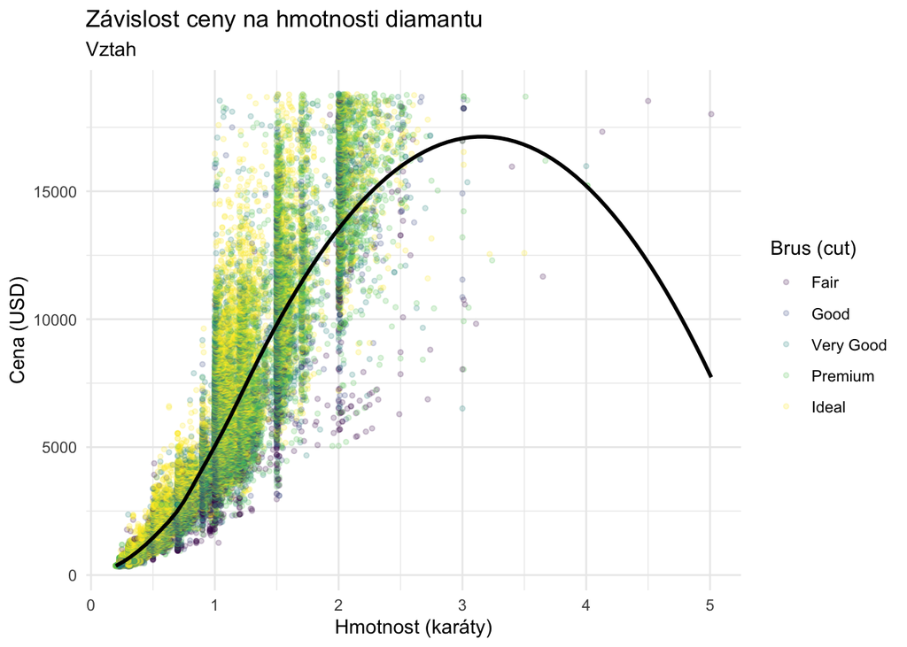

```r
ggplot(df_clean, aes(x = carat, y = price, color = cut)) +
  geom_point(alpha = 0.2, size = 1) +
  geom_smooth(method = "loess", se = FALSE, color = "black") +
  theme_minimal() +
  labs(
    title = "Závislost ceny na hmotnosti diamantu",
    subtitle = "Vztah ",
    x = "Hmotnost (karáty)",
    y = "Cena (USD)",
    color = "Brus (cut)"
  )
```

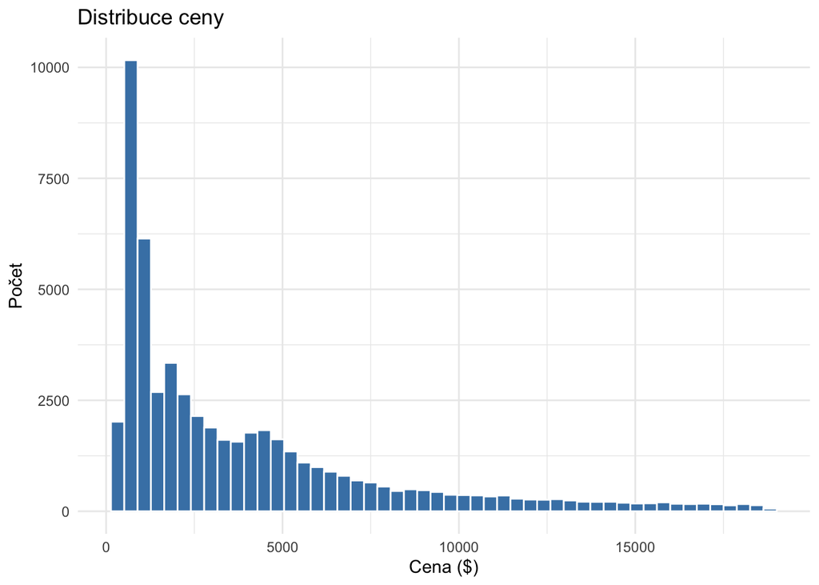

```r
# Histogram ceny
ggplot(df_clean, aes(x = price)) +
  geom_histogram(bins = 50, fill = "steelblue", color = "white") +
  theme_minimal() +
  labs(title = "Distribuce ceny", x = "Cena ($)", y = "Počet")
```

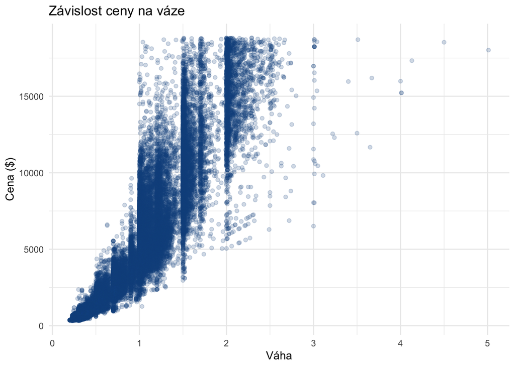

```r
# Carat vs Price
ggplot(df_clean, aes(x = carat, y = price)) +
  geom_point(alpha = 0.2, color = "dodgerblue4") +
  geom_smooth(method = "loess", color = "red") +
  theme_minimal() +
  labs(title = "Závislost ceny na váze", x = "Váha", y = "Cena ($)")
```

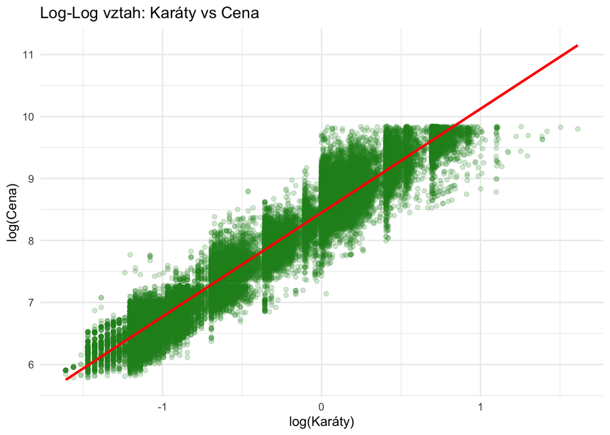

```r
# log
ggplot(df_clean, aes(x = log(carat), y = log(price))) +
  geom_point(alpha = 0.2, color = "forestgreen") +
  geom_smooth(method = "lm", color = "red") +
  theme_minimal() +
  labs(title = "Log-Log vztah: Karáty vs Cena", x = "log(Karáty)", y = "log(Cena)")
```

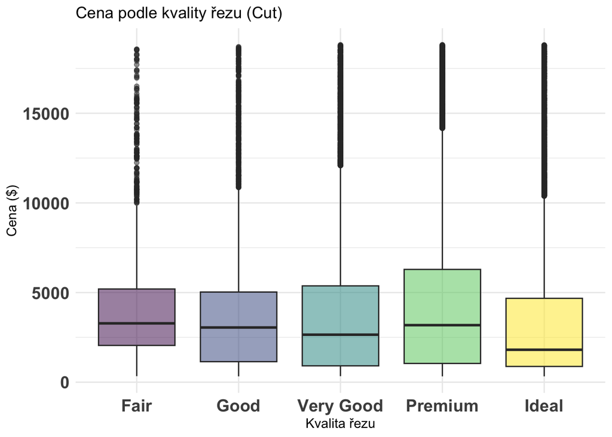

```r
#boxplot
ggplot(df_clean, aes(x = cut, y = price, fill = cut)) +
  geom_boxplot(alpha = 0.5) +
  theme_minimal() +
  theme(axis.text = element_text(size = 14, face = "bold"), legend.position = "none") +
  labs(title = "Cena podle kvality řezu (Cut)", x = "Kvalita řezu", y = "Cena ($)")
```

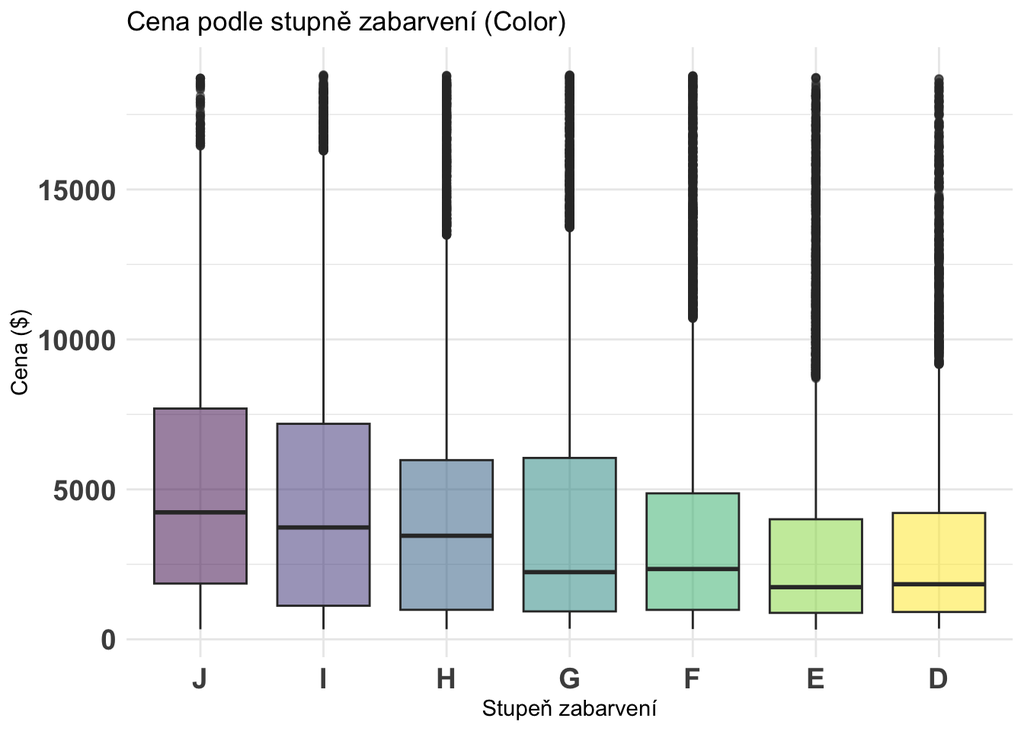

```r
ggplot(data=df_clean, aes(x = color, y = price, fill = color)) +
  geom_boxplot(alpha = 0.5) +
  theme_minimal() +
  theme(axis.text = element_text(size = 14, face = "bold"), legend.position = "none") +
  labs(title = "Cena podle stupně zabarvení (Color)", x = "Stupeň zabarvení", y = "Cena ($)")
```

- **D, E, F (Bezbarvé / Colorless):** Úplně čiré, průzračné kameny. Jsou nejvzácnější a nejdražší.
- **G, H, I, J (Téměř bezbarvé / Near Colorless):** Mají velmi slabý nádech do žluta, který je ale pro laika, a často i bez lupy, prakticky nepostřehnutelný (zvlášť po zasazení do šperku).

Proč jsou ale kameny s horším stupňem zabarvení dražší? Zkusme si to ukázat na dalším grafu.

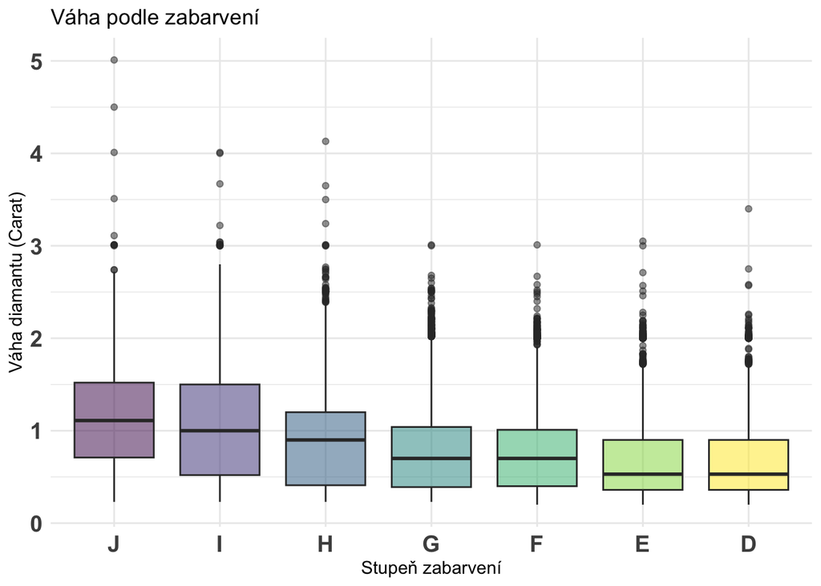

```r
ggplot(df_clean, aes(x = color, y = carat, fill = color)) +
  geom_boxplot(alpha = 0.5) +
  theme_minimal() +
  theme(axis.text = element_text(size = 14, face = "bold"), legend.position = "none") +
  labs(title = "Váha podle zabarvení", x = "Stupeň zabarvení", y = "Váha diamantu (Carat)")
```

Dále se podíváme na cenu diamantu, podle stupně čistoty.

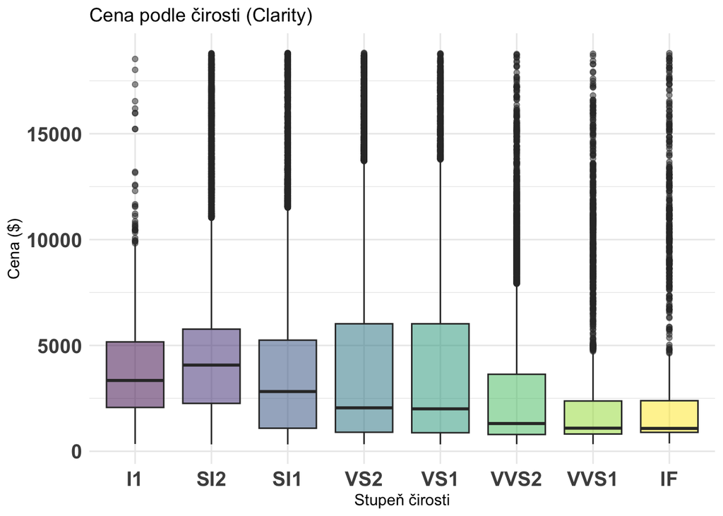

```r
ggplot(data=df_clean, aes(x = clarity, y = price, fill = clarity)) +
  geom_boxplot(alpha = 0.5) +
  theme_minimal() +
  theme(axis.text = element_text(size = 14, face = "bold"), legend.position = "none") +
  labs(title = "Cena podle čirosti (Clarity)", x = "Stupeň čirosti", y = "Cena ($)")
```

- **I1 (Included 1)** – Inkluze jsou natolik výrazné, že jsou často **viditelné i pouhým okem** a mohou snižovat průhlednost nebo lesk kamene.
- **SI1, SI2 (Slightly Included)** – Obsahují drobné inkluze, které jsou snadno viditelné pod 10× zvětšením (lupou), ale pro laika bývají **pouhým okem neviditelné**.
- **VS1, VS2 (Very Slightly Included)** – Obsahují velmi drobné vady, které jsou pod **lupou** **obtížně viditelné**.
- **VVS1, VVS2 (Very Very Slightly Included)** – Obsahují extrémně titěrné inkluze, které pod lupou **hledá i zkušený gemolog jen velmi těžko**.
- **IF (Internally Flawless)** – Zcela **čisté uvnitř** – při 10× zvětšení nemají žádné vnitřní vady (mohou mít jen nepatrné stopy na povrchu).

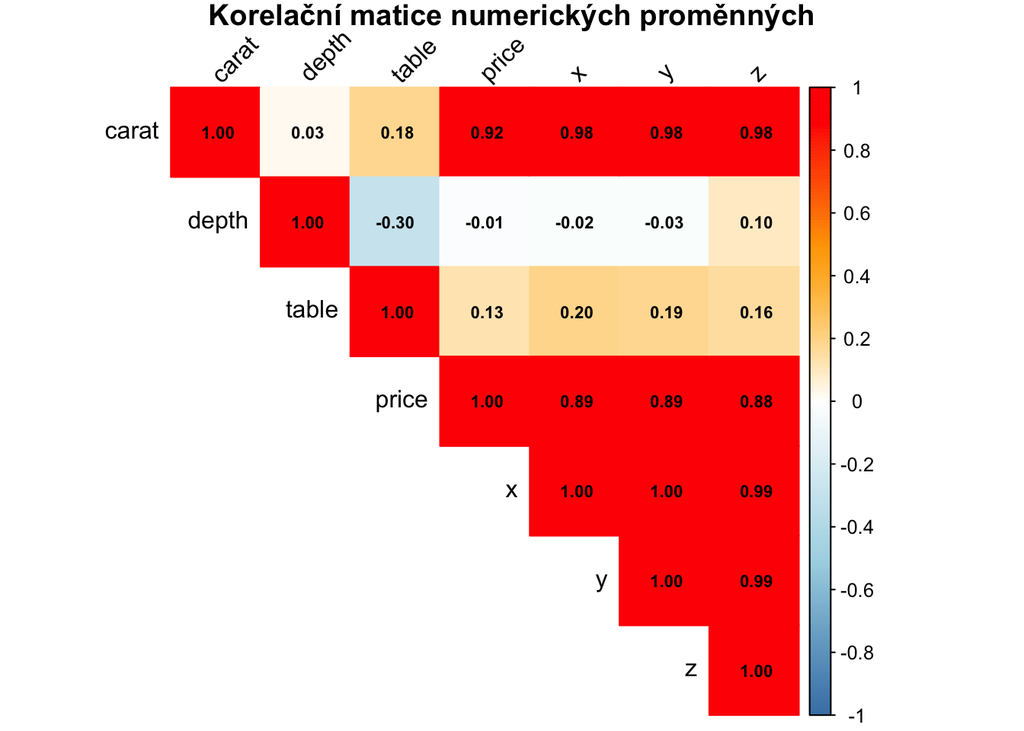

```r
num_vars <- df_clean %>% select(carat, depth, table, price, x, y, z)
cor_matrix <- cor(num_vars)

# Vykreslení korelačního diagramu
corrplot(cor_matrix, method = "color", type = "upper",
         addCoef.col = "black", tl.col = "black", tl.srt = 45,
         number.cex = 0.7, col = colorRampPalette(c("steelblue", "lightblue", "white", "orange", "red"))(200), title = "Korelační matice numerických proměnných", mar = c(0,0,1,0))
```

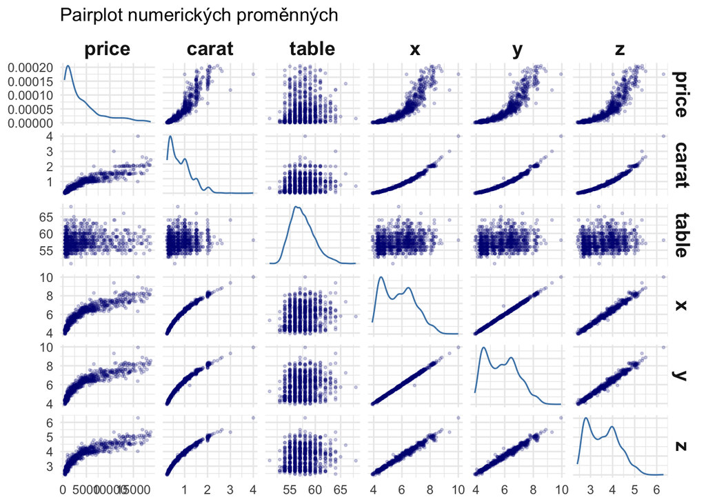

```r
pairplot_data <- df_clean |> sample_n(1000) |> select(price, carat, clarity, table, x, y, z)
ggpairs(pairplot_data, columns=c("price", "carat", "table", "x", "y", "z"),
        upper = list(continuous = wrap("points", alpha = 0.2, size = 0.6, color = "navy")),
        lower = list(continuous = wrap("points", alpha = 0.2, size = 0.6, color = "navy")),
        diag = list(continuous = wrap("densityDiag", alpha = 0.3, color = "steelblue"))) +
  theme_minimal() +
  theme(strip.text = element_text(size = 14, face = "bold"), axis.text = element_text(size = 9)) +
  labs(title = "Pairplot numerických proměnných")
```

```r
summary(lm(price ~ x + y + z, data=df_clean))
```

```
Call:
lm(formula = price ~ x + y + z, data = df_clean)

Residuals:
    Min      1Q  Median      3Q     Max
-8161.1 -1281.2  -193.4   995.8 12008.9

Coefficients:
             Estimate Std. Error  t value Pr(>|t|)
(Intercept) -14383.31      41.65 -345.353  < 2e-16 ***
x             -762.76     139.64   -5.462 4.72e-08 ***
y             3592.44     138.02   26.028  < 2e-16 ***
z              590.21      86.19    6.848 7.58e-12 ***
---
Signif. codes:  0 '***' 0.001 '**' 0.01 '*' 0.05 '.' 0.1 ' ' 1

Residual standard error: 1826 on 53916 degrees of freedom
Multiple R-squared:  0.7902,    Adjusted R-squared:  0.7902
F-statistic: 6.771e+04 on 3 and 53916 DF,  p-value: < 2.2e-16
```

```r
multi_model <- lm(price ~ carat + depth + table + cut + color + clarity + x + y + z, data = df_clean)

# View the detailed results
summary(multi_model)
```

```
Call:
lm(formula = price ~ carat + depth + table + cut + color + clarity +
    x + y + z, data = df_clean)

Residuals:
     Min       1Q   Median       3Q      Max
-21477.7   -587.9   -183.6    371.1  10755.0

Coefficients:
             Estimate Std. Error t value Pr(>|t|)
(Intercept) -1544.804    649.973  -2.377  0.01747 *
carat       11548.124     51.680 223.455  < 2e-16 ***
depth          60.485      9.551   6.333 2.42e-10 ***
table         -24.763      2.900  -8.538  < 2e-16 ***
cut.L         549.448     22.438  24.487  < 2e-16 ***
cut.Q        -249.708     18.196 -13.723  < 2e-16 ***
cut.C          87.601     16.033   5.464 4.68e-08 ***
cut^4         -40.844     12.494  -3.269  0.00108 **
color.L      1961.157     17.254 113.665  < 2e-16 ***
color.Q      -682.469     15.699 -43.473  < 2e-16 ***
color.C       165.115     14.647  11.273  < 2e-16 ***
color^4        44.116     13.456   3.278  0.00104 **
color^5        93.851     12.711   7.384 1.56e-13 ***
color^6       -46.683     11.554  -4.040 5.34e-05 ***
clarity.L    4054.367     30.225 134.139  < 2e-16 ***
clarity.Q   -1917.198     28.148 -68.111  < 2e-16 ***
clarity.C     974.390     24.079  40.467  < 2e-16 ***
clarity^4    -359.751     19.202 -18.735  < 2e-16 ***
clarity^5     231.091     15.678  14.739  < 2e-16 ***
clarity^6       3.973     13.642   0.291  0.77088
clarity^7      90.252     12.039   7.497 6.65e-14 ***
x           -1510.477    103.069 -14.655  < 2e-16 ***
y            1702.210    105.421  16.147  < 2e-16 ***
z           -2175.750    146.591 -14.842  < 2e-16 ***
---
Signif. codes:  0 '***' 0.001 '**' 0.01 '*' 0.05 '.' 0.1 ' ' 1

Residual standard error: 1124 on 53896 degrees of freedom
Multiple R-squared:  0.9206,    Adjusted R-squared:  0.9205
F-statistic: 2.716e+04 on 23 and 53896 DF,  p-value: < 2.2e-16
```

```r
anova(multi_model)
```

```
Analysis of Variance Table

Response: price
             Df     Sum Sq    Mean Sq   F value    Pr(>F)
carat         1 7.2800e+11 7.2800e+11 576343.41 < 2.2e-16 ***
depth         1 1.1603e+09 1.1603e+09    918.59 < 2.2e-16 ***
table         1 2.5678e+09 2.5678e+09   2032.91 < 2.2e-16 ***
cut           4 2.9116e+09 7.2790e+08    576.27 < 2.2e-16 ***
color         6 1.2446e+10 2.0743e+09   1642.18 < 2.2e-16 ***
clarity       7 3.8093e+10 5.4419e+09   4308.26 < 2.2e-16 ***
x             1 3.4809e+09 3.4809e+09   2755.74 < 2.2e-16 ***
y             1 1.4012e+08 1.4012e+08    110.93 < 2.2e-16 ***
z             1 2.7826e+08 2.7826e+08    220.29 < 2.2e-16 ***
Residuals 53896 6.8078e+10 1.2631e+06
---
Signif. codes:  0 '***' 0.001 '**' 0.01 '*' 0.05 '.' 0.1 ' ' 1
```

```r
multi_model <- lm(log(price) ~ carat + depth + table + cut + color + clarity + x, data = df_clean)

# View the detailed results
summary(multi_model)
```

```
Call:
lm(formula = log(price) ~ carat + depth + table + cut + color +
    clarity + x, data = df_clean)

Residuals:
     Min       1Q   Median       3Q      Max
-2.66562 -0.08680 -0.00049  0.08746  2.85479

Coefficients:
              Estimate Std. Error  t value Pr(>|t|)
(Intercept) -3.7795614  0.0468886  -80.607  < 2e-16 ***
carat       -0.9985457  0.0063545 -157.139  < 2e-16 ***
depth        0.0616292  0.0005043  122.214  < 2e-16 ***
table        0.0089260  0.0003577   24.957  < 2e-16 ***
cut.L        0.1126079  0.0027618   40.773  < 2e-16 ***
cut.Q       -0.0441912  0.0022100  -19.996  < 2e-16 ***
cut.C        0.0402953  0.0018995   21.214  < 2e-16 ***
cut^4        0.0143221  0.0015190    9.429  < 2e-16 ***
color.L      0.4432164  0.0021308  208.008  < 2e-16 ***
color.Q     -0.0940401  0.0019387  -48.507  < 2e-16 ***
color.C      0.0121989  0.0018087    6.745 1.55e-11 ***
color^4      0.0142819  0.0016617    8.595  < 2e-16 ***
color^5      0.0048662  0.0015695    3.100  0.00193 **
color^6      0.0005273  0.0014269    0.370  0.71173
clarity.L    0.9075202  0.0037214  243.863  < 2e-16 ***
clarity.Q   -0.2436443  0.0034728  -70.158  < 2e-16 ***
clarity.C    0.1330252  0.0029704   44.783  < 2e-16 ***
clarity^4   -0.0632219  0.0023707  -26.668  < 2e-16 ***
clarity^5    0.0253298  0.0019356   13.086  < 2e-16 ***
clarity^6   -0.0017779  0.0016848   -1.055  0.29129
clarity^7    0.0316401  0.0014868   21.281  < 2e-16 ***
x            1.3906359  0.0026934  516.309  < 2e-16 ***
---
Signif. codes:  0 '***' 0.001 '**' 0.01 '*' 0.05 '.' 0.1 ' ' 1

Residual standard error: 0.1388 on 53898 degrees of freedom
Multiple R-squared:  0.9813,    Adjusted R-squared:  0.9813
F-statistic: 1.346e+05 on 21 and 53898 DF,  p-value: < 2.2e-16
```

```r
anova(multi_model)
```

```
Analysis of Variance Table

Response: log(price)
             Df Sum Sq Mean Sq    F value    Pr(>F)
carat         1  46998   46998 2439412.17 < 2.2e-16 ***
depth         1     35      35    1824.47 < 2.2e-16 ***
table         1     17      17     893.08 < 2.2e-16 ***
cut           4     74      18     959.31 < 2.2e-16 ***
color         6   1014     169    8772.08 < 2.2e-16 ***
clarity       7   1184     169    8777.03 < 2.2e-16 ***
x             1   5136    5136  266574.74 < 2.2e-16 ***
Residuals 53898   1038       0
---
Signif. codes:  0 '***' 0.001 '**' 0.01 '*' 0.05 '.' 0.1 ' ' 1
```